# Exam 3

Naylor

11/20/2020

#### *Below is a summary of the results from the exam 3 skills test I created for my data analysis class’s third exam, the R file with the coding for this exam is called: “NAYLOR_Skills_Test_3.R”*

# **Part 1**

## *College faculty salaries*

The first part of the exam was to look at the different factors that can affect the salaries of professors based on their rank, tier, and state. The ranks were classified as assistant (which are not tenured professors), associate (tenured professors), and full (professors that have been around for a long time). The college tiers were based upon how much funding is used for research versus the amount used for teaching. Tier I refers to universities that spend more on funding rather than teaching.

The data (FacultySalaries_1995.csv) used for this was data collected from 1995 containing the faculty salaries and compensations. As it was raw data it needed to be cleaned first:

```r
## loaded packages
library(tidyverse)
library(broom)
library (janitor)

## Load and clean FacultySalaries_1995.csv file ##

# Loaded Data in
fs <- read_csv("FacultySalaries_1995.csv")

# get rid of un-necessary capitalization
names(fs) <- make_clean_names(names(fs))
names(fs)

# separate full professor, associate professor, associate professor, and all professors

# full professor
full <- fs %>% select(c(1:4,16), ends_with("_all"), matches("full_prof")) %>%
  pivot_longer(contains("full_prof"),
               names_to= c("measurement", "rank"),values_to="average",
               names_prefix= "avg_full_prof_",
               names_sep= "_") %>%
  mutate(rank="Full")


# associate professor
assoc <- fs %>% select(c(1:4,16), ends_with("_all"), matches("assoc_prof")) %>%
  pivot_longer(contains("assoc_prof"),
               names_to= c("measurement", "rank"),values_to="average",
               names_prefix= "avg_assoc_prof_",
               names_sep= "_") %>%
  mutate(rank="Assoc")

# assistant professor
assist <- fs %>% select(c(1:4,16), ends_with("_all"), matches("assist_prof")) %>%
  pivot_longer(contains("assist_prof"),
               names_to= c("measurement", "rank"),values_to="average",
               names_prefix= "avg_assist_prof_",
               names_sep= "_") %>%
  mutate(rank="Assist")

#combine the different ranks
full <- rbind(full,assoc,assist)

# re-make the comp, salary, and number columns
full <- full %>% pivot_wider(
  names_from = measurement,
  values_from = average)

#change rank from character to factor)
full$rank <- as.factor(full$rank)
str(full$rank)
```

Below is a summary of the cleaned data:

```r
summary(full)
```

```
##      fed_id       univ_name            state               tier
##  Min.   : 1002   Length:3483        Length:3483        Length:3483
##  1st Qu.: 1903   Class :character   Class :character   Class :character
##  Median : 2668   Mode  :character   Mode  :character   Mode  :character
##  Mean   : 3052
##  3rd Qu.: 3420
##  Max.   :29269
##
##  num_instructors  avg_prof_salary_all avg_prof_comp_all num_faculty_all
##  Min.   :  0.00   Min.   :232.0       Min.   : 265.0    Min.   :   7.0
##  1st Qu.:  2.00   1st Qu.:352.0       1st Qu.: 436.0    1st Qu.:  68.0
##  Median :  6.00   Median :407.0       Median : 510.0    Median : 132.0
##  Mean   : 12.74   Mean   :420.4       Mean   : 526.7    Mean   : 257.4
##  3rd Qu.: 14.00   3rd Qu.:475.0       3rd Qu.: 600.0    3rd Qu.: 323.0
##  Max.   :178.00   Max.   :866.0       Max.   :1075.0    Max.   :2261.0
##
##      rank          salary            comp             num
##  Assist:1161   Min.   : 199.0   Min.   : 246.0   Min.   :  0.00
##  Assoc :1161   1st Qu.: 351.0   1st Qu.: 437.0   1st Qu.: 19.00
##  Full  :1161   Median : 409.0   Median : 514.0   Median : 39.00
##                Mean   : 429.7   Mean   : 538.4   Mean   : 78.71
##                3rd Qu.: 487.0   3rd Qu.: 615.0   3rd Qu.: 95.00
##                Max.   :1009.0   Max.   :1236.0   Max.   :997.00
##                NA's   :128      NA's   :128
```

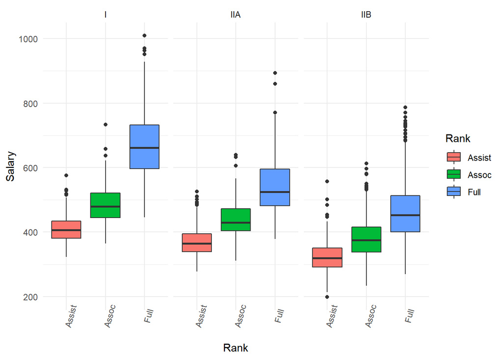

```r
p1 <- full %>% filter(tier != "VIIB") %>%
  ggplot(aes(x=rank, y=salary, fill=rank))+
  geom_boxplot() +
  facet_wrap(~tier)+
  labs(y="Salary", x="Rank", fill="Rank")+
  theme_minimal() +
  theme(axis.text.x = element_text(angle = 75))
p1
```

**FIGURE 1.1** Box-plot of salaries by rank and tier. There seems to be a positive correlation between salary and rank where a full professor has the highest average salary, followed by associate professor, and assistant professors getting the lowest average salary. Additionally, it looks as though there is a positive correlation between tier and the salary, where tier I giving the highest average salary, followed by tier IIA, then tier IIB.

The figure above was saved as NAYLOR_Fig_1.jpg:

```r
# export the graph
ggsave("NAYLOR_Fig_1.jpg",plot=p1)
```

An ANOVA model was used to test the influence of the variables: state, tier, and rank on salary. The interactions between any of the 3 variables tested within the model were not tested:

```r
# create a model using state, tier, and rank as predictors for salary
mod1 <- aov(data= full, salary ~ state + tier + rank)
```

**TABLE 1.1** Summary of the ANOVA model. There was a significant p-value of less than 0.05 for all three variable (state, tier, and rank). This suggests that the state, tier, and rank have an impact on the salary of the professor.

```r
#summary of the modal
summary(mod1)
```

```
##               Df   Sum Sq Mean Sq F value Pr(>F)
## state         51  5682396  111420   30.66 <2e-16 ***
## tier           2  7072361 3536180  972.96 <2e-16 ***
## rank           2 16529771 8264885 2274.04 <2e-16 ***
## Residuals   3299 11990072    3634
## ---
## Signif. codes:  0 '***' 0.001 '**' 0.01 '*' 0.05 '.' 0.1 ' ' 1
## 128 observations deleted due to missingness
```

The results from the ANOVA table was exported into the file named “Salary_ANOVA_Summary.txt”:

```r
#export the ANOVA table.
capture.output(summary(mod1), file="Salary_ANOVA_Summary.txt")
```

# **Part 2**

## *Chemical degradation of essential oils from dead cedar trees*

The next part of the exam examined how the different chemicals used for essential oils (derived from a number of dead cedar trees) degraded over time since the tree’s death from fire.

The data (file name “Juniper_Oils.csv”) used for this part came from a collaboration between Young Living Inc. and UVU Microbiology, where they collected dead cedar trees and measured the chemical composition of their essential oil content. It was cleaned to only contain the Chemical ID, years since the tree was burned, and the mass-spec concentrations of the chemicals:

```r
#load in the "Juniper_Oils.csv" data.
jo <- read_csv("Juniper_Oils.csv")

# select only the desired columns
jo_chem <- jo %>%
  select('alpha-pinene':thujopsenal,41) %>%
  pivot_longer(-YearsSinceBurn,
               names_to="ChemicalID",
               values_to="Concentration")
```

Below is the summary of the cleaned and specified data:

```r
summary(jo_chem)
```

```
##  YearsSinceBurn   ChemicalID        Concentration
##  Min.   : 2.00   Length:782         Min.   : 0.000
##  1st Qu.: 7.00   Class :character   1st Qu.: 0.500
##  Median :12.00   Mode  :character   Median : 1.300
##  Mean   :12.12                      Mean   : 3.793
##  3rd Qu.:18.00                      3rd Qu.: 3.175
##  Max.   :22.00                      Max.   :39.900
```

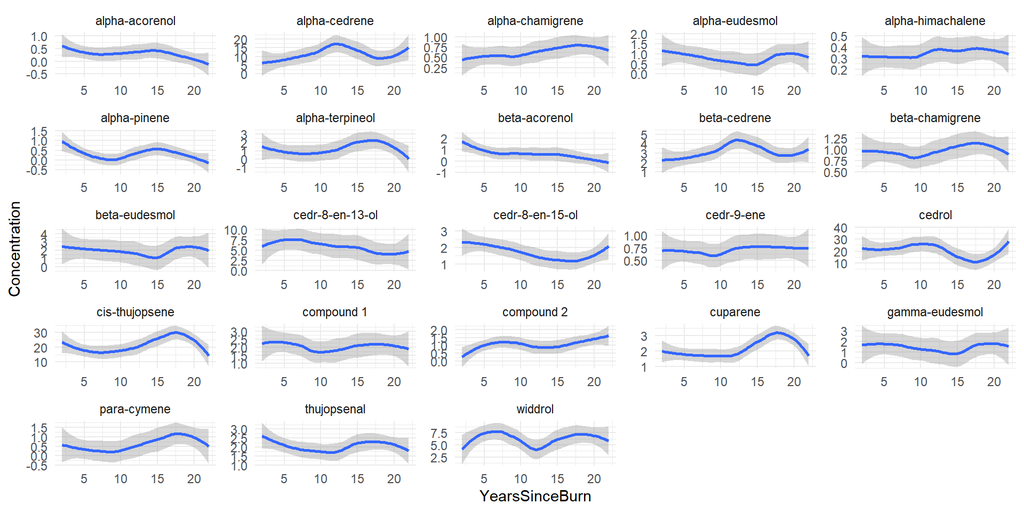

```r
p2 <- jo_chem %>%
  ggplot(aes(x=YearsSinceBurn, y=Concentration))+
  geom_smooth()+
  facet_wrap(~ChemicalID, scales= "free") +
  theme_minimal()
p2
```

**FIGURE 2.1** Plot of the smoothed conditional mean of concentration by years since the tree was burned and seperated by chemical ID. The chemicals that seemed to degrade over time are alpha-acorenol, beta-acorenol, and cedr-8-en-15-ol.

The figure above was saved as NAYLOR_Fig_2.jpg:

```r
# export the graph
ggsave("NAYLOR_Fig_2.jpg",plot=p2, width=10)
```

A generalized line model was used to test the degradation of the chemicals over time.

```r
mod2 <- lm(Concentration ~ ChemicalID * YearsSinceBurn, jo_chem)

# summarize the model
summary(mod2)

#tidy the model
tidy(mod2)
tidy_mod2= tidy(mod2)

# get the significant of less than 0.5
glm_sig <- filter(tidy_mod2, p.value < 0.05)

#clean the data to get rid of ChemicalID
glm_sig$term <- str_remove(glm_sig$term, "ChemicalID")
```

**TABLE 2.1** Summary of the generalized linear model with only the chemicals that had a significant p-value of less than 0.05. It was more likely that there would be higher than average concentrations of alpha-cedrene, cedr-8-en-13-ol, cedrol, cis-thujopsene, and widdrol. However, there was nothing significant enough to suggest that any of the chemicals degraded over time.

```r
# the table of chemicals with significance of less than 0.05
glm_sig
```

```
## # A tibble: 6 x 5
##   term                          estimate std.error statistic  p.value
##   <chr>                            <dbl>     <dbl>     <dbl>    <dbl>
## 1 alpha-cedrene                    7.88      1.93       4.08 4.97e- 5
## 2 cedr-8-en-13-ol                  7.62      1.93       3.95 8.72e- 5
## 3 cedrol                          22.5       1.93      11.7  5.12e-29
## 4 cis-thujopsene                  17.3       1.93       8.95 2.93e-18
## 5 widdrol                          5.82      1.93       3.01 2.69e- 3
## 6 cis-thujopsene:YearsSinceBurn    0.332     0.141      2.35 1.90e- 2
```